# MultiFIT: Multiscale Fisher’s Independence Test for Multivariate Dependence

S. Gorsky and L. Ma

The `MultiFIT` package includes several functions:

1. `MultiFIT`: the function that runs the test of independence of two random vectors, the algorithm comprising of multiscale $2\times2$ univariate tests of discretized margins and multiple testing adjustments. At each resolution, recursively, tests whose p-values are below a pre-set threshold are chosen and smaller portions of the sample space that correspond to those are explored in higher resolutions. The function returns a list object that contains details of the performed tests, p-values corrected according to the selected multiple testing procedure for all tests, and global p-values for the null hypothesis that the two random vectors are independent.
2. `MultiSummary`: a function that returns and plots the most significant $2\times2$ univariate tests of discretized margins.
3. `MultiTree`: a function that generates a directed acyclic graph where nodes are $2\times2$ univariate tests of discretized margins. An edge from one test to another indicates the the latter test is performed on half the portion of the sample space on which the former was performed.

## Examples

### First Example:

#### Generate Data:

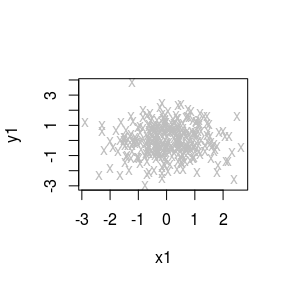

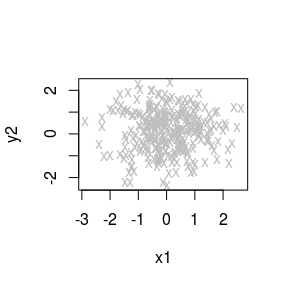

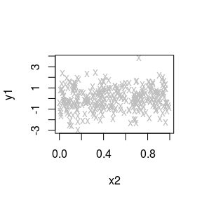

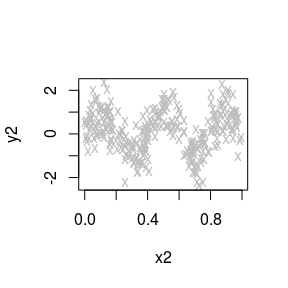

```r
set.seed(1)
# Generate data for two random vectors, each of dimension 2, 300 observations:
n = 300
x = matrix(0, ncol = 2, nrow = n)
y = matrix(0, ncol = 2, nrow = n)

# x1 and y1 are i.i.d Normal(0,1):
x[ , 1] = rnorm(n)
y[ , 1] = rnorm(n)

# x2 is a Uniform(0,1):
x[ , 2] = runif(n)

# and y2 is depends on x2 as a noisy sine function:
y[ , 2] = sin(5 * pi * x[ , 2]) + 0.6 * rnorm(n)

plot(x[ , 1], y[ , 1], col = "grey", pch = "x", xlab = "x1", ylab = "y1")
plot(x[ , 1], y[ , 2], col = "grey", pch = "x", xlab = "x1", ylab = "y2")
plot(x[ , 2], y[ , 1], col = "grey", pch = "x", xlab = "x2", ylab = "y1")
plot(x[ , 2], y[ , 2], col = "grey", pch = "x", xlab = "x2", ylab = "y2")
```

#### Run the Test:

```r
library(MultiFit)
fit = MultiFIT(x = x, y = y)
# p-values computed according to a 'holistic' strategy:
fit$p.values.holistic
```

```
##            H   Hcorrected
## 2.800233e-05 1.937348e-05
```

```r
# p-values computed according to a 'resolution-specific' strategy:
fit$p.values.resolution.specific
```

```
##           HB  HcorrectedB
## 4.923487e-05 3.406327e-05
```

In order to get a better sense of the workings of the function, choose `verbose = TRUE`:

```r
# Data may also be transferred to the function as a single list:
xy = list(x = x, y = y)
fit = MultiFIT(xy, verbose = TRUE)
```

```
## Applying rank transformation
## Testing and computing mid-p corrected p-values:
## Resolution 0/4: performing 4 tests
## Resolution 1/4: scanning 16 cuboids, performing 32 tests
## Resolution 2/4: scanning 4 cuboids, performing 16 tests
## Resolution 3/4: scanning 16 cuboids, performing 56 tests
## Resolution 4/4: scanning 12 cuboids, performing 48 tests
## No potential parents in resolution 4 have p-values below threshold.
## Time difference of 0.02655315 secs
## Individual tests completed, computing holistic p-values...
## H: Computing all adjusted holistic p-values...
## Hcorrected: Computing all adjusted holistic p-values...
## Time difference of 0.0001893044 secs
##
## Fisher's Exact Tests:
## Global holistic p-value, Holm on p-values: 2.80023e-05
## Global resolution specific p-value, Holm on p-values: 4.92349e-05
## Global holistic p-value, Holm on p-values with mid-p correction: 1.93735e-05
## Global resolution specific p-value, Holm on p-values with mid-p correction: 3.40633e-05
```

The output details the number of tests performed at each resolution. The default testing method for the marginal $2\times2$ contingency tables is Fisher’s exact test.

The default multiple testing adjustments methods we use are Holm’s method on the original p-values (`H`) and Holm’s method on the mid-p corrected p-values (`Hcorrected`). The p-value for the global null hypothesis that $\mathbf{x}$ is independent of $\mathbf{y}$ is reported for each adjustment method, and for two strategies:

*Strategy 1. A holistic approach to multiple testing.* Under this strategy, one applies multiple testing control procedure on the entire set of p-values generated from all resolutions all at once, regardless of the resolution of the corresponding table.

#### Optional Stopping Rule

An additional benefit of the resolution-specific approach is that it can be implemented with early stopping so that the MultiFIT procedure can terminate as soon as there is sufficient evidence for rejecting the global null in the first few resolutions without continuing into testing on higher resolutions. This is possible because in this approach we bound the influence of tables in finer resolutions on the corrected significance level of tests in coarser resolutions. Our software implements this early stopping strategy for the resolution-specific approach to multiple testing when Holm’s method is used for intra-resolution correction along with Bonferroni’s method for cross-resolution correction. Early stopping can reduce the time complexity significantly in the presence of a global signal.

```r
fit = MultiFIT(x = x, y = y, verbose = TRUE, apply.stopping.rule = TRUE)
```

```
## Applying rank transformation
## Testing and computing mid-p corrected p-values:
## Resolution 0/4: performing 4 tests
## Resolution 1/4: scanning 16 cuboids, performing 32 tests
## Early stopping rule met.
##
## Time difference of 0.01105762 secs
##
## Fisher's Exact Tests:
## Global resolution specific p-value, Holm on p-values: 4.92349e-05
## Global resolution specific p-value, Holm on p-values with mid-p correction: 3.40633e-05
```

#### An Approximate Version

Under the default strategy of setting $p^*$, we get that for certain alternatives, in particular those that are pervasive over the sample space and involve a large number of cuboids, the complexity of the procedure may be higher than $O(n\log n)$. Such large-scale, global alternatives, however, can usually be detected in coarse resolutions, and thus in practice when the algorithm is equipped with early stopping it will in fact run faster with larger $n$ under such alternatives.

If the practitioner wishes to ensure a strict $O(n\log n)$ bound on the computational complexity with or without incorporating early stopping, a simple approximate version of the multiscale Fisher’s independence test algorithm can achieve this.

```r
fit = MultiFIT(x = x, y = y, verbose = TRUE, ranking.approximation = TRUE, M = 10)
```

```
## Applying rank transformation
## Testing and computing mid-p corrected p-values:
## Resolution 0/4: performing 4 tests
## Resolution 1/4: scanning 16 cuboids, performing 32 tests
## Resolution 2/4: scanning 4 cuboids, performing 16 tests
## Resolution 3/4: scanning 16 cuboids, performing 56 tests
## Resolution 4/4: scanning 12 cuboids, performing 48 tests
## Time difference of 0.02700138 secs
## Individual tests completed, computing holistic p-values...
## H: Computing all adjusted holistic p-values...
## Hcorrected: Computing all adjusted holistic p-values...
## Time difference of 0.0001871586 secs
##
## Fisher's Exact Tests:
## Global holistic p-value, Holm on p-values: 2.80023e-05
## Global resolution specific p-value, Holm on p-values: 4.92349e-05
## Global holistic p-value, Holm on p-values with mid-p correction: 1.93735e-05
## Global resolution specific p-value, Holm on p-values with mid-p correction: 3.40633e-05
```

#### Summarize Results (1):

```r
MultiSummary(xy = xy, fit = fit, alpha = 0.05)
```

```
##
## The following tests had a p-value of less than 0.05:
## Ranked #1, Test 32: x2 and y2 | 0<=x2<0.46 (p-value=1.937348e-05)
```

```
## Ranked #2, Test 44: x2 and y2 | 0.22<=x2<0.46 (p-value=0.005378376)
```

```
## Ranked #3, Test 48: x2 and y2 | 0<=x2<0.46, -2.39<=y2<0.22 (p-value=0.01510365)
```

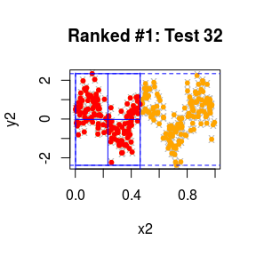

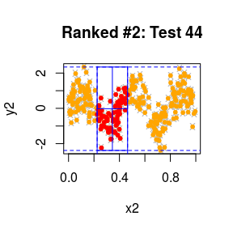

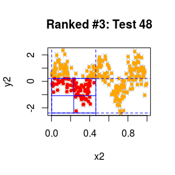

In grey and orange are all data points outside the cuboid we are testing. In orange are the points that were in the cuboid if we were not to condition on the margins that are visible in the plot. In red are the points that are inside the cuboid after we condition on all the margins, including those that are visible in a plot. The blue lines delineate the quadrants along which the discretization was performed: we count the number of red points in each quadrant, treat these four numbers as a $2\times2$ contingency table and perform a 1-degree of freedom test of independence on it (default test: Fisher’s exact test).

#### Summarize Results (2):

We may also draw a directed acyclic graph where nodes represent tests as demonstrated above in the `MultiSummary` output. An edge from one test to another indicates that the latter test is performed on half the portion of the sample space on which the former was performed. Larger nodes correspond to more extreme p-values for the test depicted in it (storing the output as a `pdf` file):

```r
# And plot a DAG representation of the ranked tests:
library(png)
library(qgraph)
MultiTree(xy = xy, fit = fit, filename = "first_example")
```

```
## Output stored in /tmp/RtmpzWaEpl/Rbuild41ae6760cf55/MultiFit/vignettes/first_example.pdf
```